# Intro to Data Science - HW 5

## Step 3: Use ggplot to explore the distribution of each variable

**Don’t forget to install and library the ggplot2 package.** Then:  
H. Create a histogram for **new_sp_m014**. Be sure to add a title and briefly describe what the histogram means in a comment.

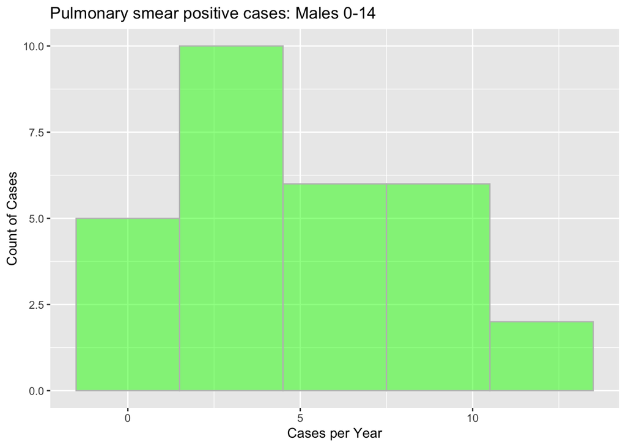

```r
library(ggplot2)
tbCan %>%
ggplot() +
geom_histogram(aes(x=new_sp_m014), fill="green",color = "grey", alpha=0.5, bins =5) +
xlab("Cases per Year") +
ylab("Count of Cases") +
ggtitle("Pulmonary smear positive cases: Males 0-14")
```

```r
#This Histogram is is showing the frequency of postive cases per year for males 0-14.
```

1. Create histograms (using ggplot) of each of the other three variables from E with ggplot( ).  
   Which parameter do you need to adjust to make the other histograms look right?

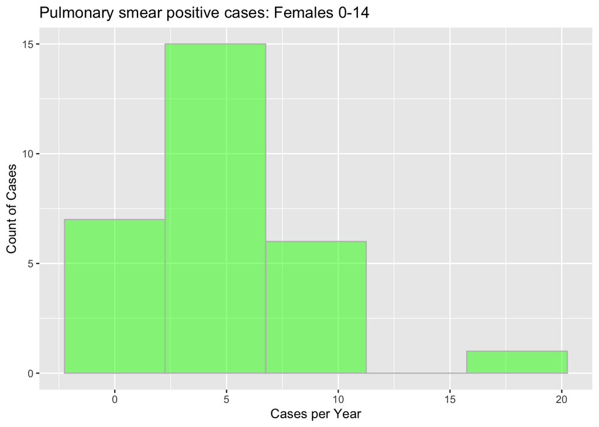

```r
tbCan %>%
ggplot() +
geom_histogram(aes(x=new_sp_f014), fill="green",color = "grey", alpha=0.5, bins =5) +
xlab("Cases per Year") +
ylab("Count of Cases") +
ggtitle("Pulmonary smear positive cases: Females 0-14")
```

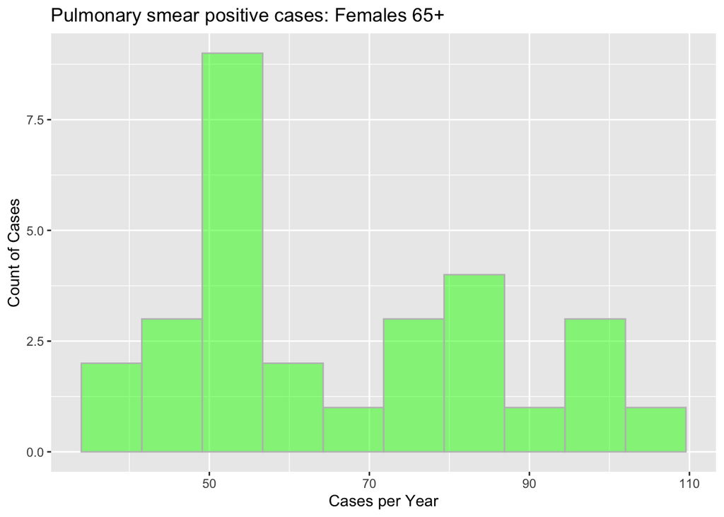

```r
tbCan %>%
ggplot() +
geom_histogram(aes(x=new_sp_f65), fill="green",color = "grey", alpha=0.5, bins =10) +
xlab("Cases per Year") +
ylab("Count of Cases") +
ggtitle("Pulmonary smear positive cases: Females 65+")
```

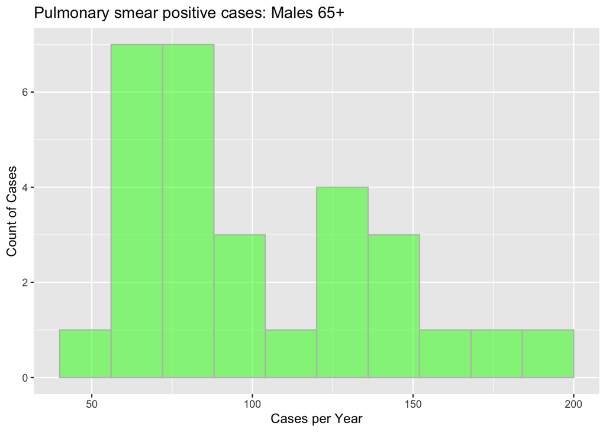

```r
tbCan %>%
ggplot() +
geom_histogram(aes(x=new_sp_m65), fill="green",color = "grey", alpha=0.5, bins =10) +
xlab("Cases per Year") +
ylab("Count of Cases") +
ggtitle("Pulmonary smear positive cases: Males 65+")
```

```r
# I adjusted the number of bins to try ot show the range a bit more clearly
```

## Step 4: Explore how the data changes over time

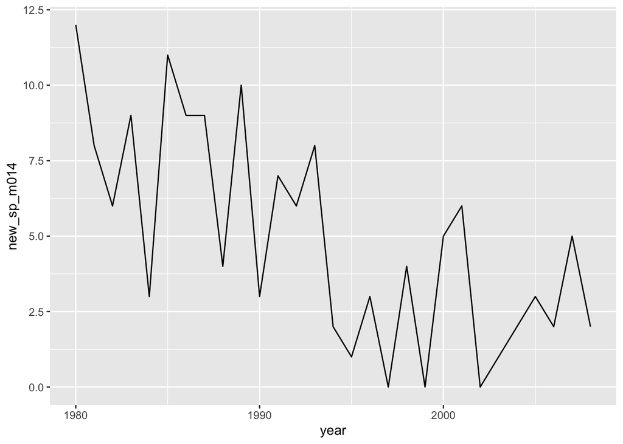

```r
tbCan %>%
ggplot() +
geom_line(aes(x=year, y=new_sp_m014))
```

11. Next, create similar graphs for each of the other three variables. Change the **color** of the line plots (any color you want).

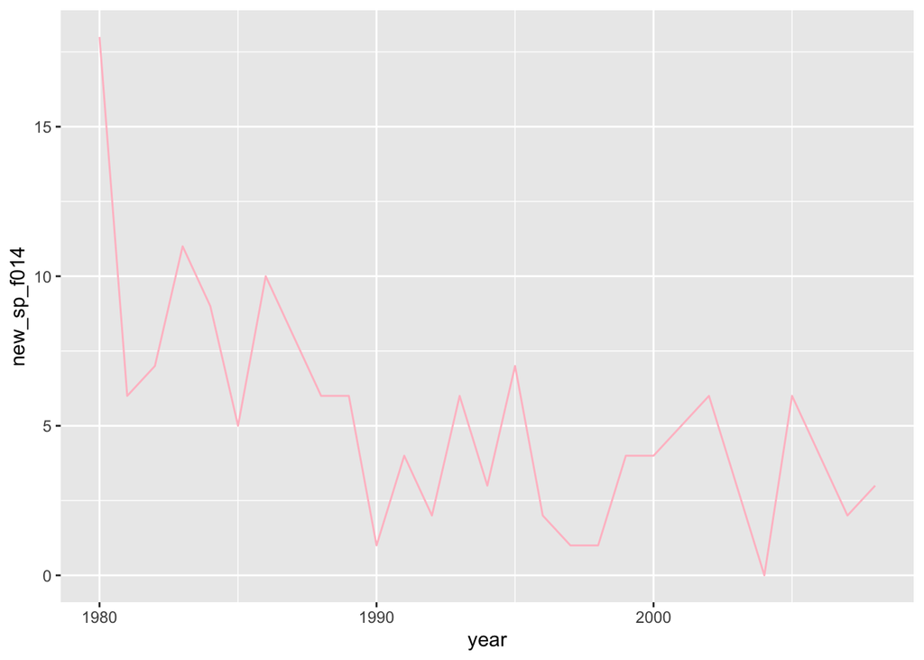

```r
tbCan %>%
ggplot() +
geom_line(aes(x=year, y=new_sp_f014),color = "pink")
```

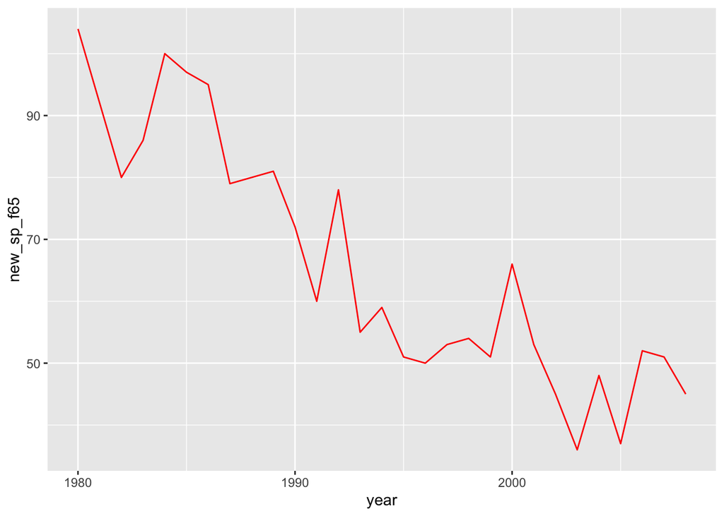

```r
tbCan %>%
ggplot() +
geom_line(aes(x=year, y=new_sp_f65),color = "red")
```

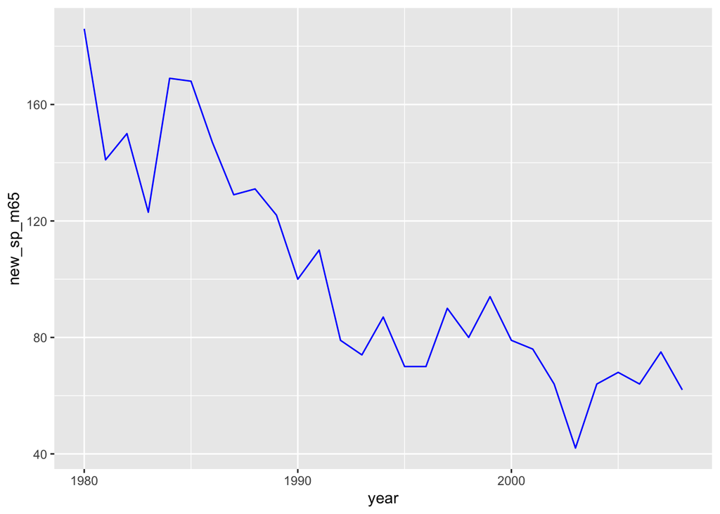

```r
tbCan %>%
ggplot() +
geom_line(aes(x=year, y=new_sp_m65),color = "blue")
```

12. Using vector math, create a new variable by combining the numbers from **new_sp_m014** and **new_sp_f014**. Save the resulting vector as a new variable in the **tbCan** df called **new_sp_combined014**. This new variable represents the number of positive pulmonary smear tests for male AND female children between the ages of 0 and 14 years of age. Do the same for SP **tests among citizens 65 years of age and older** and save the resulting vector in the tbCan variable called **new_sp_combined65**.

```r
tbCan$new_sp_combined014 <- tbCan$new_sp_m014 + tbCan$new_sp_f014
tbCan$new_sp_combined65 <- tbCan$new_sp_f65 + tbCan$new_sp_m65
```

13. Finally, create a **scatter plot**, showing **new_sp_combined014** on the x axis, **new_sp_combined65** on the y axis, and having the **color and size** of the point represent **year**.

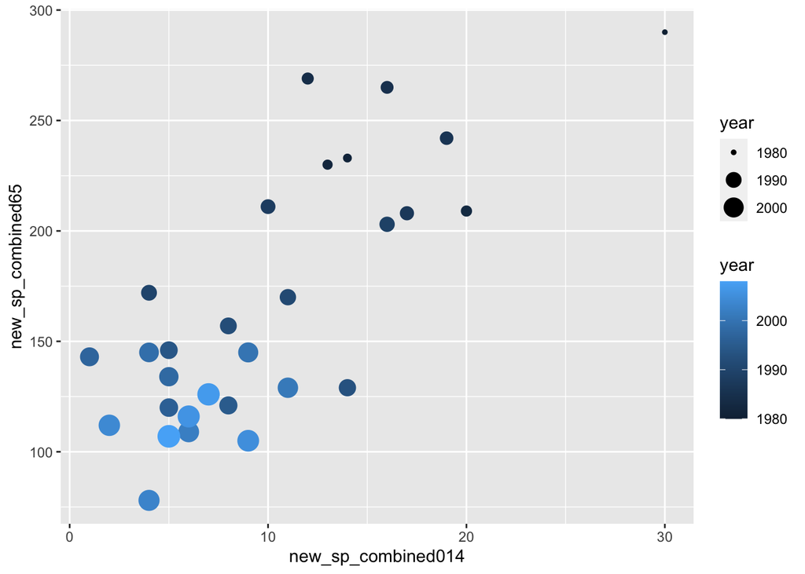

```r
tbCan %>%
ggplot(aes(x=new_sp_combined014, y = new_sp_combined65)) +
geom_point(aes(color = year, size = year))
```

14. Interpret this visualization – what insight does it provide?

```r
#This is showing that as the years increase, the number of positive tests decrease for both age groups. There is a higher concentration in the lower left quadrant, which also coresponds to 2000 and on
```